Part 1

# QUESTION 1

400/600 = 4/6 = 2/3

# question 2

# An electrical manufacturing company conducts quality checks at specified periods on the products it manufactures. Historically, the failure rate for the manufactured item is 5%. Suppose a random sample of 10 manufactured items is selected. Answer the following questions.

2.1 Probability that none of the items are defective?

0.59873

2.2 Probability that exactly one of the items is defective?

0.3151

2.4 Probability that three or more of the items are defective ?

0.01047

# Question 3

# A car salesman sells on an average 3 cars per week.

3.1 Probability that in a given week he will sell some cars

0.950213

3.2 Probability that in a given week he will sell 2 or more but less than 5 cars.

0.6163

```python
import numpy as np
import scipy.stats as stats
import matplotlib.pyplot as plt
```

# Question 4

# Accuracy in understanding orders for a speech based bot at a restaurant is important for the Company X which has designed, marketed and launched the product for a contactless delivery due to the COVID-19 pandemic. Recognition accuracy that measures the percentage of orders that are taken correctly is 86.8%. Suppose that you place order with the bot and two friends of yours independently place orders with the same bot. Answer the following questions

4.1 What is the probability that all three orders will be recognised correctly?.

0.6539

4.2 What is the probability that none of the three orders will be recognised correctly?

0.002299

4.3 What is the probability that at least two of the three orders will be recognised correctly?

0.95225

# Question 5

# A group of 300 professionals sat for a competitive exam. The results show the information of marks obtained by them have a mean of 60 and a standard deviation of 12. The pattern of marks follows a normal distribution. Answer the following questions

5.1 What is the percentage of students who score more than 80?

```python
z=(80-60)/12
z

cu_dis = stats.norm.cdf(z)
a = (1-cu_dis) * 300
a
```

```
14.33710568184441
```

5.2 What is the percentage of students who score less than 50?

```python
z=(50-60)/12
z

cu_dis = stats.norm.cdf(z)
cu_dis
a = cu_dis * 300
a
```

```
60.69851428909293
```

# Question 6

# Explain 1 real life industry scenario [other than the ones mentioned above] where you can use the concepts learnt in this module of Applied statistics to get a data driven business solution

Weather forecasting - in weather forcasting data is collected about temperature , wind speed humidity and these previously known data can be used to predict the weather of the upcoming days. Weather forcasting is very helpful in many domain , it may be used in agriculture as in when to sow seed . it may be used by logistics company to find the apt situation or day to transfer goods etc.

E-commerce companies also rely upon statistics to know maybe which is best overall selling product in a city , which product sale brings maximum profit etc . With the help os stats they can may be restock the item which is selling fast

### Part 2

Company X manages the men's top professional basketball division of the American league system. The dataset contains information on all the teams that have participated in all the past tournaments. It has data about how many baskets each team scored, conceded, how many times they came within the first 2 positions, how many tournaments they have qualified, their best position in the past, etc

```python
import pandas as pd
import numpy as np
import matplotlib.pyplot as plt
%matplotlib widget
%matplotlib inline
plt.style.use('fivethirtyeight')
import seaborn as sns
sns.set(color_codes=True)
import warnings
warnings.filterwarnings('ignore')
```

# Here we are reading csv file with the help of pandas

```python
basketball_df = pd.read_csv("basketball.csv")
```

we are printing the first five lines of the data

```python
basketball_df.head(5)
```

|  | Team | Tournament | Score | PlayedGames | WonGames | DrawnGames | LostGames | BasketScored | BasketGiven | TournamentChampion | Runner-up | TeamLaunch | HighestPositionHeld |
| --- | --- | --- | --- | --- | --- | --- | --- | --- | --- | --- | --- | --- | --- |
| 0 | Team 1 | 86 | 4385 | 2762 | 1647 | 552 | 563 | 5947 | 3140 | 33 | 23 | 1929 | 1 |
| 1 | Team 2 | 86 | 4262 | 2762 | 1581 | 573 | 608 | 5900 | 3114 | 25 | 25 | 1929 | 1 |
| 2 | Team 3 | 80 | 3442 | 2614 | 1241 | 598 | 775 | 4534 | 3309 | 10 | 8 | 1929 | 1 |
| 3 | Team 4 | 82 | 3386 | 2664 | 1187 | 616 | 861 | 4398 | 3469 | 6 | 6 | 1931to32 | 1 |
| 4 | Team 5 | 86 | 3368 | 2762 | 1209 | 633 | 920 | 4631 | 3700 | 8 | 7 | 1929 | 1 |

```python
basketball_df.shape # shape of the dataframe
```

```
(61, 13)
```

```python
basketball_df.info()
```

```
<class 'pandas.core.frame.DataFrame'>
RangeIndex: 61 entries, 0 to 60
Data columns (total 13 columns):
 #   Column               Non-Null Count  Dtype
---  ------               --------------  -----
 0   Team                 61 non-null     object
 1   Tournament           61 non-null     int64
 2   Score                61 non-null     object
 3   PlayedGames          61 non-null     object
 4   WonGames             61 non-null     object
 5   DrawnGames           61 non-null     object
 6   LostGames            61 non-null     object
 7   BasketScored         61 non-null     object
 8   BasketGiven          61 non-null     object
 9   TournamentChampion   61 non-null     object
 10  Runner-up            61 non-null     object
 11  TeamLaunch           61 non-null     object
 12  HighestPositionHeld  61 non-null     int64
dtypes: int64(2), object(11)
memory usage: 6.3+ KB
```

```python
df = basketball_df.replace('-', np.nan)
```

```python
df.drop(df.tail(1).index,inplace=True)
```

```python
df.fillna(0) #filling the null values with zeros
```

|  | Team | Tournament | Score | PlayedGames | WonGames | DrawnGames | LostGames | BasketScored | BasketGiven | TournamentChampion | Runner-up | TeamLaunch | HighestPositionHeld |
| --- | --- | --- | --- | --- | --- | --- | --- | --- | --- | --- | --- | --- | --- |
| 0 | Team 1 | 86 | 4385 | 2762 | 1647 | 552 | 563 | 5947 | 3140 | 33 | 23 | 1929 | 1 |
| 1 | Team 2 | 86 | 4262 | 2762 | 1581 | 573 | 608 | 5900 | 3114 | 25 | 25 | 1929 | 1 |
| 2 | Team 3 | 80 | 3442 | 2614 | 1241 | 598 | 775 | 4534 | 3309 | 10 | 8 | 1929 | 1 |
| 3 | Team 4 | 82 | 3386 | 2664 | 1187 | 616 | 861 | 4398 | 3469 | 6 | 6 | 1931to32 | 1 |
| 4 | Team 5 | 86 | 3368 | 2762 | 1209 | 633 | 920 | 4631 | 3700 | 8 | 7 | 1929 | 1 |
| 5 | Team 6 | 73 | 2819 | 2408 | 990 | 531 | 887 | 3680 | 3373 | 1 | 4 | 1934-35 | 1 |
| 6 | Team 7 | 82 | 2792 | 2626 | 948 | 608 | 1070 | 3609 | 3889 | 0 | 0 | 1929 | 3 |
| 7 | Team 8 | 70 | 2573 | 2302 | 864 | 577 | 861 | 3228 | 3230 | 2 | 3 | 1929 | 1 |
| 8 | Team 9 | 58 | 2109 | 1986 | 698 | 522 | 766 | 2683 | 2847 | 0 | 1 | 1939-40 | 2 |
| 9 | Team 10 | 51 | 1884 | 1728 | 606 | 440 | 682 | 2159 | 2492 | 1 | 0 | 1932-33 | 1 |
| 10 | Team 11 | 45 | 1814 | 1530 | 563 | 392 | 575 | 2052 | 2188 | 1 | 5 | 1941to42 | 1 |
| 11 | Team 12 | 51 | 1789 | 1698 | 586 | 389 | 723 | 2278 | 2624 | 0 | 0 | 1939-40 | 4 |
| 12 | Team 13 | 42 | 1471 | 1466 | 463 | 384 | 619 | 1767 | 2180 | 0 | 0 | 1948-49 | 4 |
| 13 | Team 14 | 44 | 1416 | 1428 | 453 | 336 | 639 | 1843 | 2368 | 0 | 1 | 1929 | 2 |
| 14 | Team 15 | 43 | 1389 | 1458 | 471 | 358 | 629 | 1753 | 2152 | 0 | 1 | 1944_45 | 2 |
| 15 | Team 16 | 37 | 1351 | 1318 | 426 | 327 | 565 | 1500 | 1834 | 0 | 0 | 1935-36 | 4 |
| 16 | Team 17 | 36 | 1314 | 1255 | 390 | 330 | 535 | 1421 | 1763 | 0 | 0 | 1949_50 | 4 |
| 17 | Team 18 | 38 | 1174 | 1192 | 408 | 292 | 492 | 1642 | 1951 | 0 | 0 | 1933to34 | 3 |
| 18 | Team 19 | 27 | 1148 | 988 | 333 | 256 | 399 | 1182 | 1371 | 0 | 0 | 1960-61 | 3 |
| 19 | Team 20 | 33 | 1020 | 1096 | 367 | 242 | 487 | 1347 | 1746 | 0 | 1 | 1951-52 | 2 |
| 20 | Team 21 | 17 | 970 | 646 | 266 | 172 | 208 | 892 | 789 | 0 | 1 | 1998-99 | 2 |
| 21 | Team 22 | 23 | 667 | 742 | 218 | 175 | 349 | 819 | 1157 | 0 | 0 | 1941-42 | 6 |
| 22 | Team 23 | 17 | 662 | 652 | 189 | 148 | 305 | 760 | 1088 | 0 | 0 | 1977-78 | 8 |
| 23 | Team 24 | 21 | 606 | 678 | 203 | 180 | 295 | 750 | 1022 | 0 | 0 | 1959-60 | 5 |
| 24 | Team 25 | 12 | 553 | 456 | 147 | 112 | 197 | 520 | 633 | 0 | 0 | 2004to05 | 6 |
| 25 | Team 26 | 20 | 538 | 628 | 184 | 149 | 295 | 716 | 1050 | 0 | 0 | 1935-36 | 5 |
| 26 | Team 27 | 13 | 510 | 494 | 155 | 128 | 211 | 619 | 744 | 0 | 0 | 1961-62 | 5 |
| 27 | Team 28 | 18 | 445 | 586 | 145 | 143 | 298 | 607 | 992 | 0 | 0 | 1940-41 | 11 |
| 28 | Team 29 | 12 | 421 | 380 | 125 | 81 | 174 | 458 | 623 | 0 | 0 | 1930-31 | 6 |
| 29 | Team 30 | 11 | 416 | 402 | 113 | 95 | 194 | 430 | 632 | 0 | 0 | 1963-64 | 6 |
| 30 | Team 31 | 12 | 375 | 423 | 123 | 102 | 198 | 422 | 581 | 0 | 0 | 1974-75 | 7 |
| 31 | Team 32 | 14 | 353 | 426 | 129 | 95 | 202 | 492 | 720 | 0 | 0 | 1943-44 | 4 |
| 32 | Team 33 | 12 | 343 | 448 | 104 | 127 | 217 | 393 | 662 | 0 | 0 | 1977-78 | 12 |
| 33 | Team 34 | 9 | 293 | 346 | 96 | 92 | 158 | 291 | 489 | 0 | 0 | 1987-88 | 7 |
| 34 | Team 35 | 11 | 285 | 334 | 103 | 79 | 152 | 419 | 588 | 0 | 0 | 1941-42 | 4 |
| 35 | Team 36 | 7 | 277 | 270 | 76 | 76 | 118 | 320 | 410 | 0 | 0 | 1991_92 | 7 |
| 36 | Team 37 | 6 | 242 | 228 | 62 | 56 | 110 | 244 | 366 | 0 | 0 | 2007-08 | 8 |
| 37 | Team 38 | 9 | 230 | 282 | 82 | 63 | 137 | 285 | 430 | 0 | 0 | 1962-63 | 5 |
| 38 | Team 39 | 4 | 190 | 160 | 52 | 45 | 63 | 199 | 241 | 0 | 0 | 1994-95 | 10 |
| 39 | Team 40 | 5 | 188 | 186 | 50 | 46 | 90 | 202 | 296 | 0 | 0 | 1978-79 | 8 |
| 40 | Team 41 | 6 | 168 | 204 | 59 | 50 | 95 | 216 | 310 | 0 | 0 | 1971-72 | 12 |
| 41 | Team 42 | 6 | 150 | 180 | 53 | 44 | 83 | 165 | 221 | 0 | 0 | 1963-64 | 7 |
| 42 | Team 43 | 4 | 148 | 152 | 37 | 37 | 78 | 155 | 253 | 0 | 0 | 1999to00 | 17 |
| 43 | Team 44 | 3 | 132 | 114 | 35 | 27 | 52 | 139 | 167 | 0 | 0 | 2014-15 | 10 |
| 44 | Team 45 | 7 | 107 | 130 | 43 | 21 | 66 | 227 | 308 | 0 | 0 | 1929 | 3 |
| 45 | Team 46 | 3 | 96 | 114 | 26 | 44 | 44 | 101 | 139 | 0 | 0 | 1990-91 | 9 |
| 46 | Team 47 | 4 | 91 | 116 | 34 | 16 | 66 | 181 | 295 | 0 | 0 | 1947-48 | 7 |
| 47 | Team 48 | 2 | 83 | 80 | 20 | 23 | 37 | 62 | 117 | 0 | 0 | 1996-97 | 17 |
| 48 | Team 49 | 2 | 81 | 80 | 19 | 24 | 37 | 70 | 115 | 0 | 0 | 1995-96 | 19 |
| 49 | Team 50 | 4 | 76 | 108 | 30 | 16 | 62 | 145 | 252 | 0 | 0 | 1945-46 | 10 |
| 50 | Team 51 | 3 | 71 | 90 | 29 | 13 | 48 | 121 | 183 | 0 | 0 | 1953-54 | 14 |
| 51 | Team 52 | 4 | 56 | 72 | 21 | 14 | 37 | 153 | 184 | 0 | 0 | 1929 | 6 |
| 52 | Team 53 | 2 | 52 | 68 | 17 | 18 | 33 | 71 | 116 | 0 | 0 | 1979-80 | 10 |
| 53 | Team 54 | 3 | 42 | 54 | 18 | 6 | 30 | 97 | 131 | 0 | 0 | 1929 | 8 |
| 54 | Team 55 | 2 | 40 | 68 | 13 | 14 | 41 | 70 | 182 | 0 | 0 | 1950-51 | 16 |
| 55 | Team 56 | 1 | 35 | 38 | 8 | 11 | 19 | 36 | 55 | 0 | 0 | 2016_17 | 17 |
| 56 | Team 57 | 1 | 34 | 38 | 8 | 10 | 20 | 38 | 66 | 0 | 0 | 2009-10 | 20 |
| 57 | Team 58 | 1 | 22 | 30 | 7 | 8 | 15 | 37 | 57 | 0 | 0 | 1956-57 | 16 |
| 58 | Team 59 | 1 | 19 | 30 | 7 | 5 | 18 | 51 | 85 | 0 | 0 | 1951~52 | 16 |
| 59 | Team 60 | 1 | 14 | 30 | 5 | 4 | 21 | 34 | 65 | 0 | 0 | 1955-56 | 15 |

```python
df['TeamLaunch'] = df['TeamLaunch'].str.replace('~','-')
df['TeamLaunch'] = df['TeamLaunch'].str.replace('to','-')
df['TeamLaunch'] = df['TeamLaunch'].str.replace('_','-')
```

```python
df['TeamLaunch'] = df['TeamLaunch'].str[0:4]
```

```python
df['TeamLaunch'] = df['TeamLaunch'].apply(lambda x: pd.datetime.strptime(x, '%Y'))
```

```python
df
```

|  | Team | Tournament | Score | PlayedGames | WonGames | DrawnGames | LostGames | BasketScored | BasketGiven | TournamentChampion | Runner-up | TeamLaunch | HighestPositionHeld |
| --- | --- | --- | --- | --- | --- | --- | --- | --- | --- | --- | --- | --- | --- |
| 0 | Team 1 | 86 | 4385 | 2762 | 1647 | 552 | 563 | 5947 | 3140 | 33 | 23 | 1929-01-01 | 1 |
| 1 | Team 2 | 86 | 4262 | 2762 | 1581 | 573 | 608 | 5900 | 3114 | 25 | 25 | 1929-01-01 | 1 |
| 2 | Team 3 | 80 | 3442 | 2614 | 1241 | 598 | 775 | 4534 | 3309 | 10 | 8 | 1929-01-01 | 1 |
| 3 | Team 4 | 82 | 3386 | 2664 | 1187 | 616 | 861 | 4398 | 3469 | 6 | 6 | 1931-01-01 | 1 |
| 4 | Team 5 | 86 | 3368 | 2762 | 1209 | 633 | 920 | 4631 | 3700 | 8 | 7 | 1929-01-01 | 1 |
| 5 | Team 6 | 73 | 2819 | 2408 | 990 | 531 | 887 | 3680 | 3373 | 1 | 4 | 1934-01-01 | 1 |
| 6 | Team 7 | 82 | 2792 | 2626 | 948 | 608 | 1070 | 3609 | 3889 | NaN | NaN | 1929-01-01 | 3 |
| 7 | Team 8 | 70 | 2573 | 2302 | 864 | 577 | 861 | 3228 | 3230 | 2 | 3 | 1929-01-01 | 1 |
| 8 | Team 9 | 58 | 2109 | 1986 | 698 | 522 | 766 | 2683 | 2847 | NaN | 1 | 1939-01-01 | 2 |
| 9 | Team 10 | 51 | 1884 | 1728 | 606 | 440 | 682 | 2159 | 2492 | 1 | NaN | 1932-01-01 | 1 |
| 10 | Team 11 | 45 | 1814 | 1530 | 563 | 392 | 575 | 2052 | 2188 | 1 | 5 | 1941-01-01 | 1 |
| 11 | Team 12 | 51 | 1789 | 1698 | 586 | 389 | 723 | 2278 | 2624 | NaN | NaN | 1939-01-01 | 4 |
| 12 | Team 13 | 42 | 1471 | 1466 | 463 | 384 | 619 | 1767 | 2180 | NaN | NaN | 1948-01-01 | 4 |
| 13 | Team 14 | 44 | 1416 | 1428 | 453 | 336 | 639 | 1843 | 2368 | NaN | 1 | 1929-01-01 | 2 |
| 14 | Team 15 | 43 | 1389 | 1458 | 471 | 358 | 629 | 1753 | 2152 | NaN | 1 | 1944-01-01 | 2 |
| 15 | Team 16 | 37 | 1351 | 1318 | 426 | 327 | 565 | 1500 | 1834 | NaN | NaN | 1935-01-01 | 4 |
| 16 | Team 17 | 36 | 1314 | 1255 | 390 | 330 | 535 | 1421 | 1763 | NaN | NaN | 1949-01-01 | 4 |
| 17 | Team 18 | 38 | 1174 | 1192 | 408 | 292 | 492 | 1642 | 1951 | NaN | NaN | 1933-01-01 | 3 |
| 18 | Team 19 | 27 | 1148 | 988 | 333 | 256 | 399 | 1182 | 1371 | NaN | NaN | 1960-01-01 | 3 |
| 19 | Team 20 | 33 | 1020 | 1096 | 367 | 242 | 487 | 1347 | 1746 | NaN | 1 | 1951-01-01 | 2 |
| 20 | Team 21 | 17 | 970 | 646 | 266 | 172 | 208 | 892 | 789 | NaN | 1 | 1998-01-01 | 2 |
| 21 | Team 22 | 23 | 667 | 742 | 218 | 175 | 349 | 819 | 1157 | NaN | NaN | 1941-01-01 | 6 |
| 22 | Team 23 | 17 | 662 | 652 | 189 | 148 | 305 | 760 | 1088 | NaN | NaN | 1977-01-01 | 8 |
| 23 | Team 24 | 21 | 606 | 678 | 203 | 180 | 295 | 750 | 1022 | NaN | NaN | 1959-01-01 | 5 |
| 24 | Team 25 | 12 | 553 | 456 | 147 | 112 | 197 | 520 | 633 | NaN | NaN | 2004-01-01 | 6 |
| 25 | Team 26 | 20 | 538 | 628 | 184 | 149 | 295 | 716 | 1050 | NaN | NaN | 1935-01-01 | 5 |
| 26 | Team 27 | 13 | 510 | 494 | 155 | 128 | 211 | 619 | 744 | NaN | NaN | 1961-01-01 | 5 |
| 27 | Team 28 | 18 | 445 | 586 | 145 | 143 | 298 | 607 | 992 | NaN | NaN | 1940-01-01 | 11 |
| 28 | Team 29 | 12 | 421 | 380 | 125 | 81 | 174 | 458 | 623 | NaN | NaN | 1930-01-01 | 6 |
| 29 | Team 30 | 11 | 416 | 402 | 113 | 95 | 194 | 430 | 632 | NaN | NaN | 1963-01-01 | 6 |
| 30 | Team 31 | 12 | 375 | 423 | 123 | 102 | 198 | 422 | 581 | NaN | NaN | 1974-01-01 | 7 |
| 31 | Team 32 | 14 | 353 | 426 | 129 | 95 | 202 | 492 | 720 | NaN | NaN | 1943-01-01 | 4 |
| 32 | Team 33 | 12 | 343 | 448 | 104 | 127 | 217 | 393 | 662 | NaN | NaN | 1977-01-01 | 12 |
| 33 | Team 34 | 9 | 293 | 346 | 96 | 92 | 158 | 291 | 489 | NaN | NaN | 1987-01-01 | 7 |
| 34 | Team 35 | 11 | 285 | 334 | 103 | 79 | 152 | 419 | 588 | NaN | NaN | 1941-01-01 | 4 |
| 35 | Team 36 | 7 | 277 | 270 | 76 | 76 | 118 | 320 | 410 | NaN | NaN | 1991-01-01 | 7 |
| 36 | Team 37 | 6 | 242 | 228 | 62 | 56 | 110 | 244 | 366 | NaN | NaN | 2007-01-01 | 8 |
| 37 | Team 38 | 9 | 230 | 282 | 82 | 63 | 137 | 285 | 430 | NaN | NaN | 1962-01-01 | 5 |
| 38 | Team 39 | 4 | 190 | 160 | 52 | 45 | 63 | 199 | 241 | NaN | NaN | 1994-01-01 | 10 |
| 39 | Team 40 | 5 | 188 | 186 | 50 | 46 | 90 | 202 | 296 | NaN | NaN | 1978-01-01 | 8 |
| 40 | Team 41 | 6 | 168 | 204 | 59 | 50 | 95 | 216 | 310 | NaN | NaN | 1971-01-01 | 12 |
| 41 | Team 42 | 6 | 150 | 180 | 53 | 44 | 83 | 165 | 221 | NaN | NaN | 1963-01-01 | 7 |
| 42 | Team 43 | 4 | 148 | 152 | 37 | 37 | 78 | 155 | 253 | NaN | NaN | 1999-01-01 | 17 |
| 43 | Team 44 | 3 | 132 | 114 | 35 | 27 | 52 | 139 | 167 | NaN | NaN | 2014-01-01 | 10 |
| 44 | Team 45 | 7 | 107 | 130 | 43 | 21 | 66 | 227 | 308 | NaN | NaN | 1929-01-01 | 3 |
| 45 | Team 46 | 3 | 96 | 114 | 26 | 44 | 44 | 101 | 139 | NaN | NaN | 1990-01-01 | 9 |
| 46 | Team 47 | 4 | 91 | 116 | 34 | 16 | 66 | 181 | 295 | NaN | NaN | 1947-01-01 | 7 |
| 47 | Team 48 | 2 | 83 | 80 | 20 | 23 | 37 | 62 | 117 | NaN | NaN | 1996-01-01 | 17 |
| 48 | Team 49 | 2 | 81 | 80 | 19 | 24 | 37 | 70 | 115 | NaN | NaN | 1995-01-01 | 19 |
| 49 | Team 50 | 4 | 76 | 108 | 30 | 16 | 62 | 145 | 252 | NaN | NaN | 1945-01-01 | 10 |
| 50 | Team 51 | 3 | 71 | 90 | 29 | 13 | 48 | 121 | 183 | NaN | NaN | 1953-01-01 | 14 |
| 51 | Team 52 | 4 | 56 | 72 | 21 | 14 | 37 | 153 | 184 | NaN | NaN | 1929-01-01 | 6 |
| 52 | Team 53 | 2 | 52 | 68 | 17 | 18 | 33 | 71 | 116 | NaN | NaN | 1979-01-01 | 10 |
| 53 | Team 54 | 3 | 42 | 54 | 18 | 6 | 30 | 97 | 131 | NaN | NaN | 1929-01-01 | 8 |
| 54 | Team 55 | 2 | 40 | 68 | 13 | 14 | 41 | 70 | 182 | NaN | NaN | 1950-01-01 | 16 |
| 55 | Team 56 | 1 | 35 | 38 | 8 | 11 | 19 | 36 | 55 | NaN | NaN | 2016-01-01 | 17 |
| 56 | Team 57 | 1 | 34 | 38 | 8 | 10 | 20 | 38 | 66 | NaN | NaN | 2009-01-01 | 20 |
| 57 | Team 58 | 1 | 22 | 30 | 7 | 8 | 15 | 37 | 57 | NaN | NaN | 1956-01-01 | 16 |
| 58 | Team 59 | 1 | 19 | 30 | 7 | 5 | 18 | 51 | 85 | NaN | NaN | 1951-01-01 | 16 |
| 59 | Team 60 | 1 | 14 | 30 | 5 | 4 | 21 | 34 | 65 | NaN | NaN | 1955-01-01 | 15 |

```python
df.describe()
```

|  | Tournament | HighestPositionHeld |
| --- | --- | --- |
| count | 60.000000 | 60.000000 |
| mean | 24.383333 | 7.050000 |
| std | 26.884620 | 5.315232 |
| min | 1.000000 | 1.000000 |
| 25% | 4.000000 | 3.000000 |
| 50% | 12.000000 | 6.000000 |
| 75% | 39.000000 | 10.000000 |
| max | 86.000000 | 20.000000 |

# Which team played most games ?

```python
df[['PlayedGames', 'WonGames' , 'LostGames']]= df[['PlayedGames', 'WonGames' , 'LostGames']].astype(str).astype(int)
teams_gplayed = df[['Team','PlayedGames']]
teams_gplayed.sort_values(by="PlayedGames" , ascending = False)
```

|  | Team | PlayedGames |
| --- | --- | --- |
| 0 | Team 1 | 2762 |
| 1 | Team 2 | 2762 |
| 4 | Team 5 | 2762 |
| 3 | Team 4 | 2664 |
| 6 | Team 7 | 2626 |
| 2 | Team 3 | 2614 |
| 5 | Team 6 | 2408 |
| 7 | Team 8 | 2302 |
| 8 | Team 9 | 1986 |
| 9 | Team 10 | 1728 |
| 11 | Team 12 | 1698 |
| 10 | Team 11 | 1530 |
| 12 | Team 13 | 1466 |
| 14 | Team 15 | 1458 |
| 13 | Team 14 | 1428 |
| 15 | Team 16 | 1318 |
| 16 | Team 17 | 1255 |
| 17 | Team 18 | 1192 |
| 19 | Team 20 | 1096 |
| 18 | Team 19 | 988 |
| 21 | Team 22 | 742 |
| 23 | Team 24 | 678 |
| 22 | Team 23 | 652 |
| 20 | Team 21 | 646 |
| 25 | Team 26 | 628 |
| 27 | Team 28 | 586 |
| 26 | Team 27 | 494 |
| 24 | Team 25 | 456 |
| 32 | Team 33 | 448 |
| 31 | Team 32 | 426 |
| 30 | Team 31 | 423 |
| 29 | Team 30 | 402 |
| 28 | Team 29 | 380 |
| 33 | Team 34 | 346 |
| 34 | Team 35 | 334 |
| 37 | Team 38 | 282 |
| 35 | Team 36 | 270 |
| 36 | Team 37 | 228 |
| 40 | Team 41 | 204 |
| 39 | Team 40 | 186 |
| 41 | Team 42 | 180 |
| 38 | Team 39 | 160 |
| 42 | Team 43 | 152 |
| 44 | Team 45 | 130 |
| 46 | Team 47 | 116 |
| 45 | Team 46 | 114 |
| 43 | Team 44 | 114 |
| 49 | Team 50 | 108 |
| 50 | Team 51 | 90 |
| 47 | Team 48 | 80 |
| 48 | Team 49 | 80 |
| 51 | Team 52 | 72 |
| 52 | Team 53 | 68 |
| 54 | Team 55 | 68 |
| 53 | Team 54 | 54 |
| 55 | Team 56 | 38 |
| 56 | Team 57 | 38 |
| 57 | Team 58 | 30 |
| 58 | Team 59 | 30 |
| 59 | Team 60 | 30 |

```python
name = teams_gplayed['Team'].head(10)
games_total = teams_gplayed['PlayedGames'].head(10)
```

```
<BarContainer object of 10 artists>
```

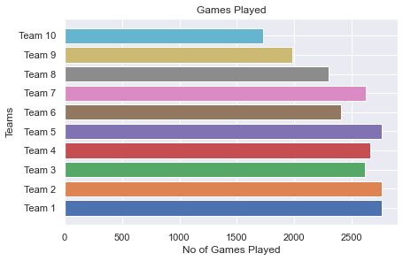

```python
plt.title("Games Played")
plt.xlabel('No of Games Played')
plt.ylabel("Teams")
plt.barh(name,games_total , color=sns.color_palette())
```

# -----------------------------------------------------------------------------------------------------------------

## Which Team Won most No of Games?

```python
teams_gwon = df[['Team','WonGames']]
teams_gwon.sort_values(by="WonGames" , ascending = False)
```

|  | Team | WonGames |
| --- | --- | --- |
| 0 | Team 1 | 1647 |
| 1 | Team 2 | 1581 |
| 2 | Team 3 | 1241 |
| 4 | Team 5 | 1209 |
| 3 | Team 4 | 1187 |
| 5 | Team 6 | 990 |
| 6 | Team 7 | 948 |
| 7 | Team 8 | 864 |
| 8 | Team 9 | 698 |
| 9 | Team 10 | 606 |
| 11 | Team 12 | 586 |
| 10 | Team 11 | 563 |
| 14 | Team 15 | 471 |
| 12 | Team 13 | 463 |
| 13 | Team 14 | 453 |
| 15 | Team 16 | 426 |
| 17 | Team 18 | 408 |
| 16 | Team 17 | 390 |
| 19 | Team 20 | 367 |
| 18 | Team 19 | 333 |
| 20 | Team 21 | 266 |
| 21 | Team 22 | 218 |
| 23 | Team 24 | 203 |
| 22 | Team 23 | 189 |
| 25 | Team 26 | 184 |
| 26 | Team 27 | 155 |
| 24 | Team 25 | 147 |
| 27 | Team 28 | 145 |
| 31 | Team 32 | 129 |
| 28 | Team 29 | 125 |
| 30 | Team 31 | 123 |
| 29 | Team 30 | 113 |
| 32 | Team 33 | 104 |
| 34 | Team 35 | 103 |
| 33 | Team 34 | 96 |
| 37 | Team 38 | 82 |
| 35 | Team 36 | 76 |
| 36 | Team 37 | 62 |
| 40 | Team 41 | 59 |
| 41 | Team 42 | 53 |
| 38 | Team 39 | 52 |
| 39 | Team 40 | 50 |
| 44 | Team 45 | 43 |
| 42 | Team 43 | 37 |
| 43 | Team 44 | 35 |
| 46 | Team 47 | 34 |
| 49 | Team 50 | 30 |
| 50 | Team 51 | 29 |
| 45 | Team 46 | 26 |
| 51 | Team 52 | 21 |
| 47 | Team 48 | 20 |
| 48 | Team 49 | 19 |
| 53 | Team 54 | 18 |
| 52 | Team 53 | 17 |
| 54 | Team 55 | 13 |
| 55 | Team 56 | 8 |
| 56 | Team 57 | 8 |
| 57 | Team 58 | 7 |
| 58 | Team 59 | 7 |
| 59 | Team 60 | 5 |

```python
name = teams_gwon['Team'].head(10)
games_lost = teams_gwon['WonGames'].head(10)
```

```
<BarContainer object of 10 artists>
```

[figure not shown]

```python
plt.title("Games Lost")
plt.xlabel('No of Games Lost')
plt.ylabel("Teams")
plt.barh(name,games_lost , color=sns.color_palette())
```

## From the above graph we can come to the conclusion that **Team 1 - Team 2 - Team 3** have also won most no of games. ------------------------------------------------------------------------------------------------------------------

## Lost Games Distribution

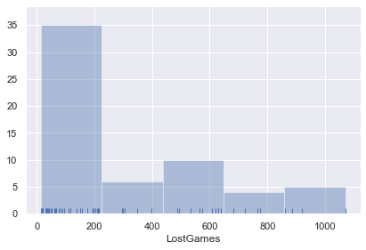

```python
sns.distplot(df['LostGames'], kde=False, rug=True);
```

```python
lost = df.loc[df['LostGames'] > 1000]
lost
```

|  | Team | Tournament | Score | PlayedGames | WonGames | DrawnGames | LostGames | BasketScored | BasketGiven | TournamentChampion | Runner-up | TeamLaunch | HighestPositionHeld |
| --- | --- | --- | --- | --- | --- | --- | --- | --- | --- | --- | --- | --- | --- |
| 6 | Team 7 | 82 | 2792 | 2626 | 948 | 608 | 1070 | 3609 | 3889 | NaN | NaN | 1929-01-01 | 3 |

```python
df['LostGames'].describe()
```

```
count      60.000000
mean      308.816667
std       294.508639
min        15.000000
25%        62.750000
50%       197.500000
75%       563.500000
max      1070.000000
Name: LostGames, dtype: float64
```

## Team 7 has lost most no of games. The minimum no of games a team have lost is 15 and the maximum is 1070 , with a mean value of 308 ------------------------------------------------------------------------------------------------------------------

## Which Team Won Most No of Championship?

```python
champions_df  = df[["Team" , "TournamentChampion"]]
champions_df['TournamentChampion'] = champions_df['TournamentChampion'].astype(str).astype(float)
chmp_df = champions_df.nlargest(5, 'TournamentChampion').loc[:,['Team','TournamentChampion']]
```

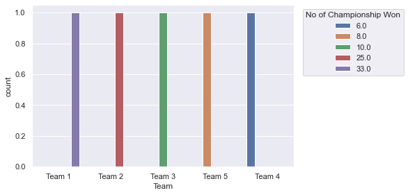

```python
sns.countplot(chmp_df['Team'],hue=chmp_df['TournamentChampion']);
plt.legend(bbox_to_anchor=(1.02, 1), loc='upper left', title='No of Championship Won')
```

## From the above graph we can come to the conclusion that **Team 1 - Team 2 - Team 3** have also won most no of championship ----------------------------------------------------------------------------------------------------------------</b2>

## Which Teams came most time as Runner Ups ?

```python
runners_df  = df[["Team" , "Runner-up"]]
runners_df['Runner-up'] = runners_df['Runner-up'].astype(str).astype(float)
runner_df = runners_df.nlargest(5, 'Runner-up').loc[:,['Team','Runner-up']]
```

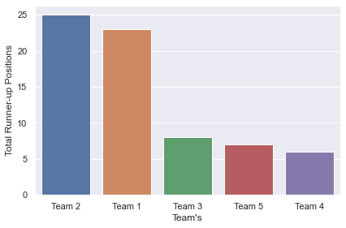

```python
bar_plot1 = sns.barplot(runner_df['Team'], runner_df['Runner-up']);

bar_plot1.set(xlabel="Team's", ylabel='Total Runner-up Positions')
plt.show()
```

## From the above graph we can come to the conclusion that **Team 1 - Team 2 - Team 3** have also won most no of Runner-up postions too ----------------------------------------------------------------------------------------------------------------

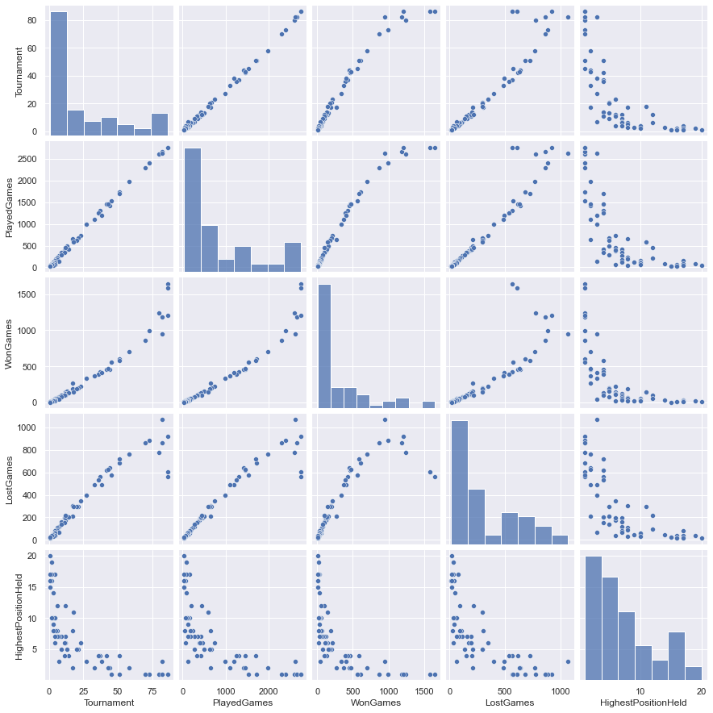

```python
sns.pairplot(df);
```

## Basket Ratio

```python
pd.options.display.float_format = '{:,.2f}'.format

df['BasketScored'] = df['BasketScored'].astype(int)
df['BasketGiven'] = df['BasketGiven'].astype(int)
```

```python
df["BasketRatio"] = df["BasketScored"] / (df["BasketScored"] +  df["BasketGiven"])
basketratio_df = df.nlargest(5, 'BasketRatio').loc[:,['Team','BasketRatio']]
```

```python
basketratio_df = basketratio_df.sort_values(by="BasketRatio" ,ascending = False).head(10)

p = pd.pivot_table(data=basketratio_df,index=['Team'])
p.head()
```

| Team | BasketRatio |
| --- | --- |
| Team 1 | 0.65 |
| Team 2 | 0.65 |
| Team 3 | 0.58 |
| Team 4 | 0.56 |
| Team 5 | 0.56 |

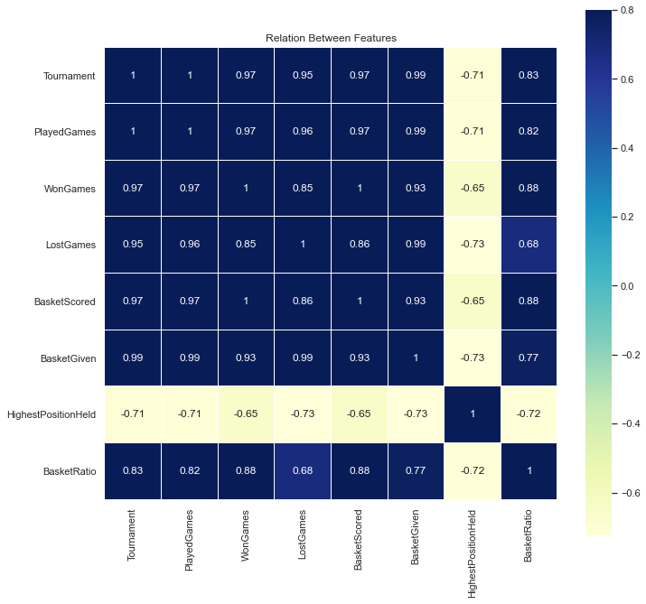

```python
corr = df.corr()
plt.figure(figsize=(10, 10))

sns.heatmap(corr, vmax=.8, linewidths=0.01,
            square=True,annot=True,cmap='YlGnBu',linecolor="white")
plt.title('Relation Between Features')
```

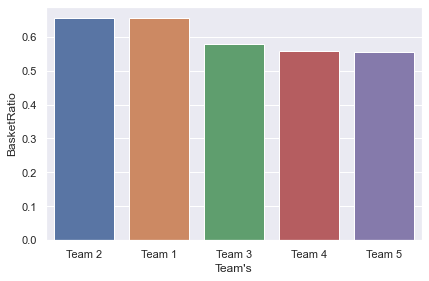

```python
bar_plot1 = sns.barplot(basketratio_df['Team'], basketratio_df['BasketRatio']);

bar_plot1.set(xlabel="Team's", ylabel='BasketRatio')
plt.show()
```

## WinRatio

```python
df['WonGames'] = df['WonGames'].astype(int)
df['PlayedGames'] = df['PlayedGames'].astype(int)
```

```python
df["WinRatio"] = df["WonGames"] / df["PlayedGames"]
df
```

|  | Team | Tournament | Score | PlayedGames | WonGames | DrawnGames | LostGames | BasketScored | BasketGiven | TournamentChampion | Runner-up | TeamLaunch | HighestPositionHeld | BasketRatio | WinRatio |
| --- | --- | --- | --- | --- | --- | --- | --- | --- | --- | --- | --- | --- | --- | --- | --- |
| 0 | Team 1 | 86 | 4385 | 2762 | 1647 | 552 | 563 | 5947 | 3140 | 33 | 23 | 1929-01-01 | 1 | 0.65 | 0.60 |
| 1 | Team 2 | 86 | 4262 | 2762 | 1581 | 573 | 608 | 5900 | 3114 | 25 | 25 | 1929-01-01 | 1 | 0.65 | 0.57 |
| 2 | Team 3 | 80 | 3442 | 2614 | 1241 | 598 | 775 | 4534 | 3309 | 10 | 8 | 1929-01-01 | 1 | 0.58 | 0.47 |
| 3 | Team 4 | 82 | 3386 | 2664 | 1187 | 616 | 861 | 4398 | 3469 | 6 | 6 | 1931-01-01 | 1 | 0.56 | 0.45 |
| 4 | Team 5 | 86 | 3368 | 2762 | 1209 | 633 | 920 | 4631 | 3700 | 8 | 7 | 1929-01-01 | 1 | 0.56 | 0.44 |
| 5 | Team 6 | 73 | 2819 | 2408 | 990 | 531 | 887 | 3680 | 3373 | 1 | 4 | 1934-01-01 | 1 | 0.52 | 0.41 |
| 6 | Team 7 | 82 | 2792 | 2626 | 948 | 608 | 1070 | 3609 | 3889 | NaN | NaN | 1929-01-01 | 3 | 0.48 | 0.36 |
| 7 | Team 8 | 70 | 2573 | 2302 | 864 | 577 | 861 | 3228 | 3230 | 2 | 3 | 1929-01-01 | 1 | 0.50 | 0.38 |
| 8 | Team 9 | 58 | 2109 | 1986 | 698 | 522 | 766 | 2683 | 2847 | NaN | 1 | 1939-01-01 | 2 | 0.49 | 0.35 |
| 9 | Team 10 | 51 | 1884 | 1728 | 606 | 440 | 682 | 2159 | 2492 | 1 | NaN | 1932-01-01 | 1 | 0.46 | 0.35 |
| 10 | Team 11 | 45 | 1814 | 1530 | 563 | 392 | 575 | 2052 | 2188 | 1 | 5 | 1941-01-01 | 1 | 0.48 | 0.37 |
| 11 | Team 12 | 51 | 1789 | 1698 | 586 | 389 | 723 | 2278 | 2624 | NaN | NaN | 1939-01-01 | 4 | 0.46 | 0.35 |
| 12 | Team 13 | 42 | 1471 | 1466 | 463 | 384 | 619 | 1767 | 2180 | NaN | NaN | 1948-01-01 | 4 | 0.45 | 0.32 |
| 13 | Team 14 | 44 | 1416 | 1428 | 453 | 336 | 639 | 1843 | 2368 | NaN | 1 | 1929-01-01 | 2 | 0.44 | 0.32 |
| 14 | Team 15 | 43 | 1389 | 1458 | 471 | 358 | 629 | 1753 | 2152 | NaN | 1 | 1944-01-01 | 2 | 0.45 | 0.32 |
| 15 | Team 16 | 37 | 1351 | 1318 | 426 | 327 | 565 | 1500 | 1834 | NaN | NaN | 1935-01-01 | 4 | 0.45 | 0.32 |
| 16 | Team 17 | 36 | 1314 | 1255 | 390 | 330 | 535 | 1421 | 1763 | NaN | NaN | 1949-01-01 | 4 | 0.45 | 0.31 |
| 17 | Team 18 | 38 | 1174 | 1192 | 408 | 292 | 492 | 1642 | 1951 | NaN | NaN | 1933-01-01 | 3 | 0.46 | 0.34 |
| 18 | Team 19 | 27 | 1148 | 988 | 333 | 256 | 399 | 1182 | 1371 | NaN | NaN | 1960-01-01 | 3 | 0.46 | 0.34 |
| 19 | Team 20 | 33 | 1020 | 1096 | 367 | 242 | 487 | 1347 | 1746 | NaN | 1 | 1951-01-01 | 2 | 0.44 | 0.33 |
| 20 | Team 21 | 17 | 970 | 646 | 266 | 172 | 208 | 892 | 789 | NaN | 1 | 1998-01-01 | 2 | 0.53 | 0.41 |
| 21 | Team 22 | 23 | 667 | 742 | 218 | 175 | 349 | 819 | 1157 | NaN | NaN | 1941-01-01 | 6 | 0.41 | 0.29 |
| 22 | Team 23 | 17 | 662 | 652 | 189 | 148 | 305 | 760 | 1088 | NaN | NaN | 1977-01-01 | 8 | 0.41 | 0.29 |
| 23 | Team 24 | 21 | 606 | 678 | 203 | 180 | 295 | 750 | 1022 | NaN | NaN | 1959-01-01 | 5 | 0.42 | 0.30 |
| 24 | Team 25 | 12 | 553 | 456 | 147 | 112 | 197 | 520 | 633 | NaN | NaN | 2004-01-01 | 6 | 0.45 | 0.32 |
| 25 | Team 26 | 20 | 538 | 628 | 184 | 149 | 295 | 716 | 1050 | NaN | NaN | 1935-01-01 | 5 | 0.41 | 0.29 |
| 26 | Team 27 | 13 | 510 | 494 | 155 | 128 | 211 | 619 | 744 | NaN | NaN | 1961-01-01 | 5 | 0.45 | 0.31 |
| 27 | Team 28 | 18 | 445 | 586 | 145 | 143 | 298 | 607 | 992 | NaN | NaN | 1940-01-01 | 11 | 0.38 | 0.25 |
| 28 | Team 29 | 12 | 421 | 380 | 125 | 81 | 174 | 458 | 623 | NaN | NaN | 1930-01-01 | 6 | 0.42 | 0.33 |
| 29 | Team 30 | 11 | 416 | 402 | 113 | 95 | 194 | 430 | 632 | NaN | NaN | 1963-01-01 | 6 | 0.40 | 0.28 |
| 30 | Team 31 | 12 | 375 | 423 | 123 | 102 | 198 | 422 | 581 | NaN | NaN | 1974-01-01 | 7 | 0.42 | 0.29 |
| 31 | Team 32 | 14 | 353 | 426 | 129 | 95 | 202 | 492 | 720 | NaN | NaN | 1943-01-01 | 4 | 0.41 | 0.30 |
| 32 | Team 33 | 12 | 343 | 448 | 104 | 127 | 217 | 393 | 662 | NaN | NaN | 1977-01-01 | 12 | 0.37 | 0.23 |
| 33 | Team 34 | 9 | 293 | 346 | 96 | 92 | 158 | 291 | 489 | NaN | NaN | 1987-01-01 | 7 | 0.37 | 0.28 |
| 34 | Team 35 | 11 | 285 | 334 | 103 | 79 | 152 | 419 | 588 | NaN | NaN | 1941-01-01 | 4 | 0.42 | 0.31 |
| 35 | Team 36 | 7 | 277 | 270 | 76 | 76 | 118 | 320 | 410 | NaN | NaN | 1991-01-01 | 7 | 0.44 | 0.28 |
| 36 | Team 37 | 6 | 242 | 228 | 62 | 56 | 110 | 244 | 366 | NaN | NaN | 2007-01-01 | 8 | 0.40 | 0.27 |
| 37 | Team 38 | 9 | 230 | 282 | 82 | 63 | 137 | 285 | 430 | NaN | NaN | 1962-01-01 | 5 | 0.40 | 0.29 |
| 38 | Team 39 | 4 | 190 | 160 | 52 | 45 | 63 | 199 | 241 | NaN | NaN | 1994-01-01 | 10 | 0.45 | 0.33 |
| 39 | Team 40 | 5 | 188 | 186 | 50 | 46 | 90 | 202 | 296 | NaN | NaN | 1978-01-01 | 8 | 0.41 | 0.27 |
| 40 | Team 41 | 6 | 168 | 204 | 59 | 50 | 95 | 216 | 310 | NaN | NaN | 1971-01-01 | 12 | 0.41 | 0.29 |
| 41 | Team 42 | 6 | 150 | 180 | 53 | 44 | 83 | 165 | 221 | NaN | NaN | 1963-01-01 | 7 | 0.43 | 0.29 |
| 42 | Team 43 | 4 | 148 | 152 | 37 | 37 | 78 | 155 | 253 | NaN | NaN | 1999-01-01 | 17 | 0.38 | 0.24 |
| 43 | Team 44 | 3 | 132 | 114 | 35 | 27 | 52 | 139 | 167 | NaN | NaN | 2014-01-01 | 10 | 0.45 | 0.31 |
| 44 | Team 45 | 7 | 107 | 130 | 43 | 21 | 66 | 227 | 308 | NaN | NaN | 1929-01-01 | 3 | 0.42 | 0.33 |
| 45 | Team 46 | 3 | 96 | 114 | 26 | 44 | 44 | 101 | 139 | NaN | NaN | 1990-01-01 | 9 | 0.42 | 0.23 |
| 46 | Team 47 | 4 | 91 | 116 | 34 | 16 | 66 | 181 | 295 | NaN | NaN | 1947-01-01 | 7 | 0.38 | 0.29 |
| 47 | Team 48 | 2 | 83 | 80 | 20 | 23 | 37 | 62 | 117 | NaN | NaN | 1996-01-01 | 17 | 0.35 | 0.25 |
| 48 | Team 49 | 2 | 81 | 80 | 19 | 24 | 37 | 70 | 115 | NaN | NaN | 1995-01-01 | 19 | 0.38 | 0.24 |
| 49 | Team 50 | 4 | 76 | 108 | 30 | 16 | 62 | 145 | 252 | NaN | NaN | 1945-01-01 | 10 | 0.37 | 0.28 |
| 50 | Team 51 | 3 | 71 | 90 | 29 | 13 | 48 | 121 | 183 | NaN | NaN | 1953-01-01 | 14 | 0.40 | 0.32 |
| 51 | Team 52 | 4 | 56 | 72 | 21 | 14 | 37 | 153 | 184 | NaN | NaN | 1929-01-01 | 6 | 0.45 | 0.29 |
| 52 | Team 53 | 2 | 52 | 68 | 17 | 18 | 33 | 71 | 116 | NaN | NaN | 1979-01-01 | 10 | 0.38 | 0.25 |
| 53 | Team 54 | 3 | 42 | 54 | 18 | 6 | 30 | 97 | 131 | NaN | NaN | 1929-01-01 | 8 | 0.43 | 0.33 |
| 54 | Team 55 | 2 | 40 | 68 | 13 | 14 | 41 | 70 | 182 | NaN | NaN | 1950-01-01 | 16 | 0.28 | 0.19 |
| 55 | Team 56 | 1 | 35 | 38 | 8 | 11 | 19 | 36 | 55 | NaN | NaN | 2016-01-01 | 17 | 0.40 | 0.21 |
| 56 | Team 57 | 1 | 34 | 38 | 8 | 10 | 20 | 38 | 66 | NaN | NaN | 2009-01-01 | 20 | 0.37 | 0.21 |
| 57 | Team 58 | 1 | 22 | 30 | 7 | 8 | 15 | 37 | 57 | NaN | NaN | 1956-01-01 | 16 | 0.39 | 0.23 |
| 58 | Team 59 | 1 | 19 | 30 | 7 | 5 | 18 | 51 | 85 | NaN | NaN | 1951-01-01 | 16 | 0.38 | 0.23 |
| 59 | Team 60 | 1 | 14 | 30 | 5 | 4 | 21 | 34 | 65 | NaN | NaN | 1955-01-01 | 15 | 0.34 | 0.17 |

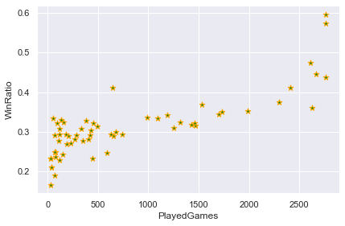

```python
plt.scatter('PlayedGames', 'WinRatio' ,data=df , marker='*' ,  color='green',edgecolor='orange',s = 50.0 )
plt.xlabel('PlayedGames')
plt.ylabel('WinRatio')
plt.show()
```

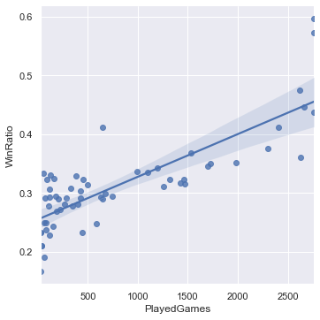

```python
sns.lmplot(y="WinRatio", x="PlayedGames", data=df);
```

## From the above graph we can come to the conclusion that , there is a relation between no of games played & win-ratio

- Quality of data could be improved. Because there were so many null values in dataset. we had no information on some teams like whether the team have won any championship etc. So the data given was unbalanced if we have look at the no of games played minimum no of games played is 30 whereas the maximum no of games played is 2762
- we generally require a large dataset to infer something. but in this case even though the data is limited , quality of the data could have been better
- Some teams have have played comparitively low no of games than teams. this may be a bad side as the data showed teams which played more no of games have some advantage in winratio
- Next time around maybe a separate dataset could we be arranged for teams who have played most and least no of games
- An extra data column about where the match was played could have beed added like whether its a Home or Away match. we could also check whether there is any relation between games played and where they have played
- Another columns could be added to see if one team have any particular edge over the other team
- TeamLaunch year also doesnt follow same pattern , a generic form would have been better

## PART - 3

```python
import pandas as pd
import numpy as np
```

```python
company_df = pd.read_csv("companyx.csv") # reading the data
```

```python
company_df.head(5)
```

|  | Startup | Product | Funding | Event | Result | OperatingState |
| --- | --- | --- | --- | --- | --- | --- |
| 0 | 2600Hz | 2600hz.com | NaN | Disrupt SF 2013 | Contestant | Operating |
| 1 | 3DLT | 3dlt.com | $630K | Disrupt NYC 2013 | Contestant | Closed |
| 2 | 3DPrinterOS | 3dprinteros.com | NaN | Disrupt SF 2016 | Contestant | Operating |
| 3 | 3Dprintler | 3dprintler.com | $1M | Disrupt NY 2016 | Audience choice | Operating |
| 4 | 42 Technologies | 42technologies.com | NaN | Disrupt NYC 2013 | Contestant | Operating |

```python
company_df.shape
```

```
(662, 6)
```

```python
#copy of the dataframe
company = company_df.copy()
```

```python
company_df.dtypes
```

```
Startup           object
Product           object
Funding           object
Event             object
Result            object
OperatingState    object
dtype: object
```

# Data exploration

```python
company_df.info()
```

```
<class 'pandas.core.frame.DataFrame'>
RangeIndex: 662 entries, 0 to 661
Data columns (total 6 columns):
 #   Column          Non-Null Count  Dtype
---  ------          --------------  -----
 0   Startup         662 non-null    object
 1   Product         656 non-null    object
 2   Funding         448 non-null    object
 3   Event           662 non-null    object
 4   Result          662 non-null    object
 5   OperatingState  662 non-null    object
dtypes: object(6)
memory usage: 31.2+ KB
```

```python
company_df = company_df.dropna()
```

# Data preprocessing & visualisation:

Creating a standard norm to show the funding (in Millions)

```python
Funds_M = []
count = 1
for ele in company_df['Funding']:

    if "K" in ele:
        temp_k = float(ele[1:-1])*1000
        ele = temp_k / 1000000
        Funds_M.append(ele)
        count = count + 1
    elif "M" in ele:
        temp_m = float(ele[1:-1])
        ele = temp_m
        Funds_M.append(ele)
        count = count + 1
    elif "B" in ele:
        temp_b = float(ele[1:-1])*1000
        ele = temp_b
        Funds_M.append(ele)
        count = count + 1
```

```python
n=company_df.columns[2]
company_df.drop(n, axis = 1, inplace = True)
```

```python
company_df['Funds_Million-$'] = Funds_M
```

```python
company_df['Funds_Million-$'].describe()
```

```
count     446.00
mean       17.24
std        90.48
min         0.01
25%         0.75
50%         2.20
75%         9.47
max     1,700.00
Name: Funds_Million-$, dtype: float64
```

```python
import matplotlib.pyplot as plt
%matplotlib widget
%matplotlib inline
plt.style.use('fivethirtyeight')
import seaborn as sns
sns.set(color_codes=True)
```

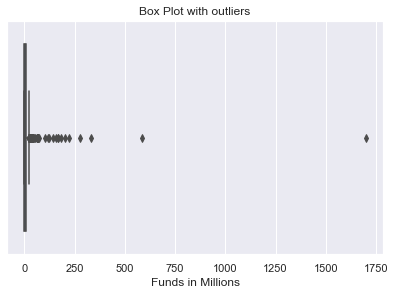

```python
sns.boxplot(x = company_df['Funds_Million-$']);
plt.xlabel("Funds in Millions")
plt.title("Box Plot with outliers")
plt.figure(figsize=(18,10));
```

There are so many outliers in the data, there so many data-points outside the maximum quartile

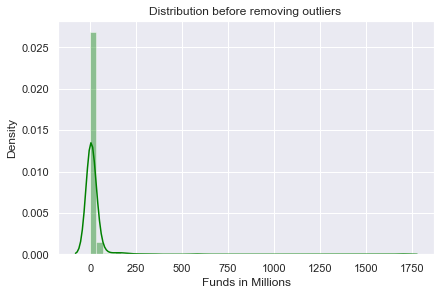

```python
sns.distplot(company_df['Funds_Million-$'] , color="green")
plt.title("Distribution before removing outliers ")
plt.xlabel("Funds in Millions")
```

We here , find the upper fence and lower fence to get rid of the ouliers , to get better clarity on the data

```python
qtr1 = pd.DataFrame(company_df).quantile(0.25)[0]
qtr3 = pd.DataFrame(company_df).quantile(0.75)[0]
iqr = qtr3 - qtr1
print(iqr)

upper_fence = qtr3 + (1.5*iqr)
lower_fence = qtr1 - (1.5*iqr)
```

```
8.72975
```

```python
#print(qtr1 , qtr3)
print(lower_fence , upper_fence)
```

```
-12.349374999999998 22.569625
```

The lower fence value of the box plot is -12.34 and high fence value of the plot is 22.569

```python
outlier_df = company_df[company_df['Funds_Million-$'] > upper_fence] # we are removing the ouliers which is beyond the upper fence
```

```python
outlier_df.reset_index(drop = True).head(5)
```

|  | Startup | Product | Event | Result | OperatingState | Funds_Million-$ |
| --- | --- | --- | --- | --- | --- | --- |
| 0 | 8 Securities | 8securities.com | Disrupt Beijing 2011 | Finalist | Operating | 29.00 |
| 1 | Anyclip | anyclip.com | TC50 2009 | Finalist | Operating | 24.00 |
| 2 | Artsy | artsy.net | Disrupt NYC 2010 | Contestant | Operating | 50.90 |
| 3 | Badgeville | badgeville.com | Disrupt SF 2010 | Finalist | Acquired | 40.00 |
| 4 | Betterment | betterment.com | Disrupt NYC 2010 | Finalist | Operating | 205.00 |

```python
outlier_df.shape
```

```
(60, 6)
```

There are 60 points which have a higher value than the upper fence value

```python
company_df.drop(company_df[company_df["Funds_Million-$"] > upper_fence].index , inplace =True)
```

```python
company_df.reset_index(drop = True).shape
```

```
(386, 6)
```

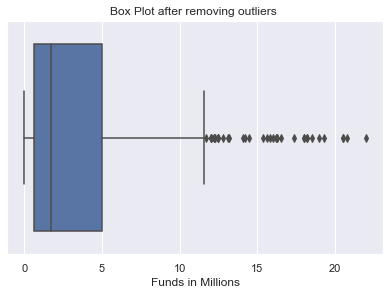

```python
sns.boxplot(company_df["Funds_Million-$"])
plt.title("Box Plot after removing outliers ")
plt.xlabel("Funds in Millions")
plt.figure(figsize=(18,10))
```

The above boxplot shows the diagram / plot after removing the outliers from the data

```python
company_df.OperatingState.value_counts()
```

```
Operating    275
Closed        56
Acquired      55
Name: OperatingState, dtype: int64
```

The below count plot shows the frequency distribution of the classes

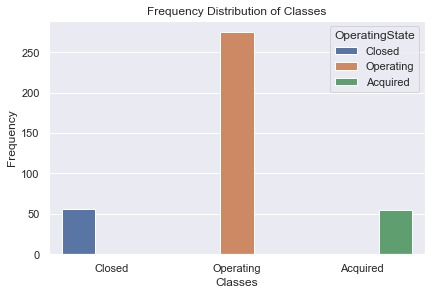

```python
sns.countplot(company_df['OperatingState'],hue=company_df['OperatingState']);
plt.title('Frequency Distribution of Classes', fontsize=12)
plt.xlabel('Classes')
plt.ylabel('Frequency')
plt.show()
```

**Plot a distribution plot for Funds in million.**

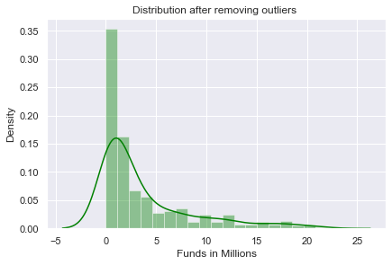

```python
sns.distplot(company_df['Funds_Million-$'], kde=True ,color = 'green')
plt.title("Distribution after removing outliers ")
plt.xlabel("Funds in Millions")
```

**• Plot distribution plots for companies still operating and companies that closed**

```python
classes_df = company_df[(company_df['OperatingState']=='Closed') | (company_df['OperatingState']=='Operating')]
```

```python
classes_df.reset_index(drop= True).head(5)
```

|  | Startup | Product | Event | Result | OperatingState | Funds_Million-$ |
| --- | --- | --- | --- | --- | --- | --- |
| 0 | 3DLT | 3dlt.com | Disrupt NYC 2013 | Contestant | Closed | 0.63 |
| 1 | 3Dprintler | 3dprintler.com | Disrupt NY 2016 | Audience choice | Operating | 1.00 |
| 2 | AdhereTech | adheretech.com | Hardware Battlefield 2014 | Contestant | Operating | 1.80 |
| 3 | AdRocket | adrocket.com | TC50 2008 | Contestant | Closed | 1.00 |
| 4 | Agrilyst | agrilyst.com | Disrupt SF 2015 | Winner | Operating | 1.00 |

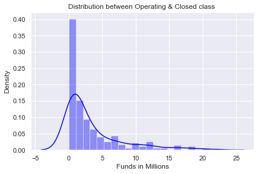

```python
sns.distplot(classes_df['Funds_Million-$'], kde=True ,color = 'blue')
plt.title("Distribution between Operating & Closed class ")
plt.xlabel("Funds in Millions")
```

# **Statistical analysis**

Is there any significant difference between Funds raised by companies that are still operating vs companies that closed down? Write the null hypothesis and alternative hypothesis. Test for significance and conclusion

H0 = There is no significant difference between funds raised by operating and closed comapnies  
Ha = There is significant difference between funds raised by operating and closed comapnies

There is no specific level of significance mention, so we consider the default 0.05 - 5%

```python
company_closed = company_df[company_df['OperatingState'] == 'Closed']['Funds_Million-$']
company_closed.reset_index(drop=True)
company_closed.describe()
```

```
count   56.00
mean     2.68
std      4.06
min      0.09
25%      0.44
50%      0.93
75%      3.12
max     20.80
Name: Funds_Million-$, dtype: float64
```

```python
company_operating = company_df[company_df['OperatingState'] == 'Operating']['Funds_Million-$']
company_operating.reset_index(drop=True)
company_operating.describe()
```

```
count   275.00
mean      3.52
std       4.43
min       0.01
25%       0.58
50%       1.70
75%       4.50
max      22.00
Name: Funds_Million-$, dtype: float64
```

```python
from statsmodels.stats.weightstats import ztest

alpha = 0.05 # level of significance
test_hypo , p_value = ztest(company_closed , company_operating)
```

```python
print("The P_value is : ",p_value)
```

```
The P_value is :  0.1922631485716917
```

```python
if p_value <= alpha:
    print("we reject the Null Hypothesis")
else:
    print("We fail to reject the Null Hypothesis")
```

```
We fail to reject the Null Hypothesis
```

The p_value is greater than the significance level , so we here fail to reject the null hypothesis. so its clear that there is no significant difference in funds between the two classes.

```python
#copy of the dataframe
company_df_copy = company.copy(deep = True)
```

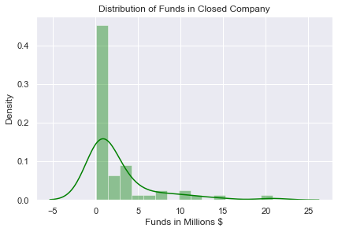

```python
company_df.columns
sns.distplot(company_df[(company_df['OperatingState'] == 'Closed')]['Funds_Million-$'],color = 'green')
plt.title("Distribution of Funds in Closed Company")
plt.xlabel("Funds in Millions $")
```

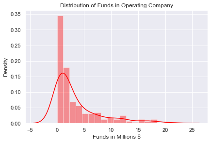

```python
sns.distplot(company_df[(company_df['OperatingState'] == 'Operating')]['Funds_Million-$'],color = 'red')
plt.title("Distribution of Funds in Operating Company")
plt.xlabel("Funds in Millions $")
```

percentage of winners that are still operating and percentage of contestants that are still operating

```python
percentages = company_df_copy[(company_df_copy['OperatingState']=='Operating') &(company_df_copy['Result']=='Winner')]
percentages.reset_index(drop =True)
pwin_val = percentages.Result.value_counts()['Winner']
percentages['Result'].value_counts()/company_df_copy['Result'].count()*100
```

```
Winner   2.87
Name: Result, dtype: float64
```

The whole dataset had 2.87% of data points which are winners and still operating

```python
percentage_con = company_df_copy[(company_df_copy['OperatingState']=='Operating') &(company_df_copy['Result']=='Contestant')]
percentage_con.reset_index(drop=True)
pcon_val = percentage_con.Result.value_counts()['Contestant']
percentage_con['Result'].value_counts()/company_df_copy['Result'].count()*100
```

```
Contestant   50.15
Name: Result, dtype: float64
```

```python
print(pwin_val , pcon_val)
```

```
19 332
```

The whole dataset had 50.15% of data points which are Contestant and still operating

Write your hypothesis comparing the proportion of companies that are operating between winners and contestants:  
Write the null hypothesis and alternative hypothesis.  
Test for significance and conclusion  
H0 = The proportions of the companies in operating states are the same  
Ha = There is significant difference in proportions of companies which are in Operating State

```python
company_df_copy.Result.value_counts()
```

```
Contestant         488
Finalist            84
Audience choice     41
Winner              26
Runner up           23
Name: Result, dtype: int64
```

```python
operating_contestant = percentage_con['Result'].value_counts()
operating_winners = percentages['Result'].value_counts()
```

Lets see the proportions between them

```python
contestant_count = company_df_copy.Result.value_counts()["Contestant"]
winner_count = company_df_copy.Result.value_counts()["Winner"]

contestants = operating_contestant/contestant_count
winners = operating_winners/winner_count
print(contestant_count ,winner_count )
```

```
488 26
```

```python
print(contestants , winners)
```

```
Contestant   0.68
Name: Result, dtype: float64 Winner   0.73
Name: Result, dtype: float64
```

There are is some difference in the proportion between the two

```python
from statsmodels.stats.proportion import proportions_ztest

alpha = 0.05 # level of significance
test_hypo , p_value = proportions_ztest([pcon_val , pwin_val],[contestant_count , winner_count])
```

```python
p_value
```

```
0.5902046211143621
```

```python
if p_value <= alpha:
    print("we reject the Null Hypothesis")
else:
    print("We fail to reject the Null Hypothesis")
```

```
We fail to reject the Null Hypothesis
```

The p_value is greater than the significance level , so we here fail to reject the null hypothesis. its clear that there is no significant differences in proportion between winners and contestant in the operating state.

# Distribution of the event variable

```python
events = company_df.Event.value_counts()
```

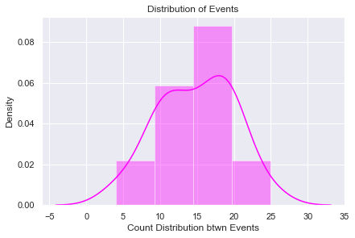

```python
sns.distplot(events,color = 'magenta')
plt.title("Distribution of Events")
plt.xlabel("Count Distribution btwn Events")
```

```python
'''
events_df = []
for ele in company_df['Event']:

    if ("Disrupt" in ele) and (int(ele[-4:])>=2013):
        events_df.append(ele)
'''
```

```
'\nevents_df = []\nfor ele in company_df[\'Event\']:\n    \n    if ("Disrupt" in ele) and (int(ele[-4:])>=2013):\n        events_df.append(ele)\n'
```

```python
'''
from pandas import DataFrame
df = DataFrame(events_df,columns=["Event"])

eve = df.Event.value_counts()

sns.distplot(eve,color = 'magenta')
plt.title("Distribution of Events from 2013")
plt.xlabel("Count Distribution btwn Events")
'''
```

```
'\nfrom pandas import DataFrame\ndf = DataFrame(events_df,columns=["Event"])\n\neve = df.Event.value_counts()\n\nsns.distplot(eve,color = \'magenta\')\nplt.title("Distribution of Events from 2013")\nplt.xlabel("Count Distribution btwn Events")\n'
```

```python
company_events =  company_df[company_df.Event.apply(lambda x: 'Disrupt' in x and int(x[-4:]) > 2013)].Event
company_events.reset_index(drop=True)
```

```
0          Disrupt NY 2016
1          Disrupt SF 2015
2      Disrupt London 2016
3          Disrupt SF 2015
4         Disrupt NYC 2014
              ...
133        Disrupt NY 2015
134        Disrupt SF 2015
135        Disrupt NY 2015
136        Disrupt SF 2014
137    Disrupt London 2015
Name: Event, Length: 138, dtype: object
```

```python
company_events
```

```
3          Disrupt NY 2016
13         Disrupt SF 2015
14     Disrupt London 2016
16         Disrupt SF 2015
18        Disrupt NYC 2014
              ...
633        Disrupt NY 2015
634        Disrupt SF 2015
635        Disrupt NY 2015
642        Disrupt SF 2014
646    Disrupt London 2015
Name: Event, Length: 138, dtype: object
```

Getting the index number and corresponding data from Funds_Million-$ column

```python
NY_events = company_df.loc[company_events[company_events.apply(lambda x: 'NY' in x)].index, 'Funds_Million-$']
SF_events = company_df.loc[company_events[company_events.apply(lambda x: 'SF' in x)].index, 'Funds_Million-$']
EU_events = company_df.loc[company_events[company_events.apply(lambda x: 'EU' in x)].index, 'Funds_Million-$']
```

H0 = The Funds raised by companies from these 3 regions are the same  
Ha = The Funds raised by companies from these 3 regions is not same

```python
NY_events.describe()
NY_mean = NY_events.mean()
SF_mean = SF_events.mean()
EU_mean = EU_events.mean()
```

```python
from scipy.stats import f_oneway

test_hypo, p_value = f_oneway(NY_events, SF_events, EU_events)
```

```python
p_value
```

```
0.8285064822945694
```

```python
if p_value <= alpha:
    print("we reject the Null Hypothesis")
else:
    print("We fail to reject the Null Hypothesis")
```

```
We fail to reject the Null Hypothesis
```

The p_value is greater than the significance level , so we here fail to reject the null hypothesis. its clear that there is no significant differences in funds raised by the companies in respect with the cities.

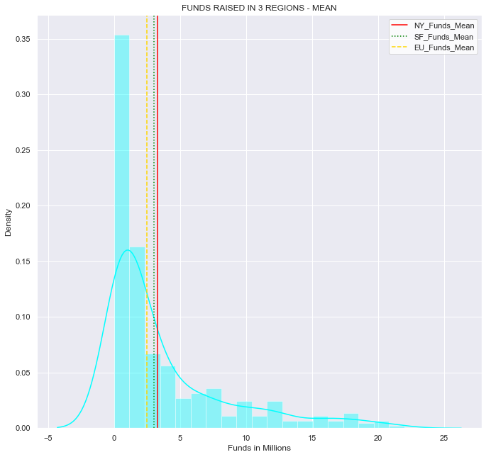

```python
fig, ax = plt.subplots(figsize=(10, 10))
sns.set_style("white")

sns.distplot(company_df['Funds_Million-$'],color ='cyan' , ax=ax );
plt.axvline(NY_mean, color = 'red', linestyle = 'solid', label = 'NY_Funds_Mean')
plt.axvline(SF_mean, color = 'green', linestyle = 'dotted', label = 'SF_Funds_Mean')
plt.axvline(EU_mean, color = 'gold', linestyle = '--', label = 'EU_Funds_Mean')
plt.xlabel("Funds in Millions");
plt.title("FUNDS RAISED IN 3 REGIONS - MEAN");
plt.legend();
plt.show()
```

5 Write your observations on improvements or suggestions on quality, quantity, variety, velocity, veracity etc. on the data points collected to perform a better data analysis.

The overall quality and quantity of the data was good enough .  
There was adequate data to infer something meaningful.  
The funds could be collected using s standard norm like in millions / Thousands etc  
if there was column for company issued / started date , we could have tried to look data in some other way